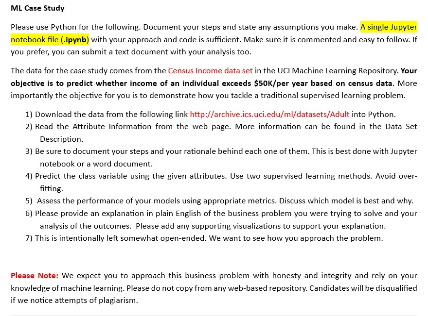

```python
#display image using python
from IPython.display import Image
url = r'C:\Users\nithi\OneDrive\Desktop\full stack data science & ai with chatgpt\8AUGUST\30 Aug-Naive bayes classifier\ML Case Study\q1.jpg'
Image(url,height=300,width=800)
```

# Problem statement:

```
Predict whether income exceeds $50K/yr based on census data. Also known as "Census Income" dataset.
```

# Attribute information:

Listing of attributes: >50K, <=50K. age: continuous. workclass: Private, Self-emp-not-inc, Self-emp-inc, Federal-gov, Local-gov, State-gov, Without-pay, Never-worked. fnlwgt: continuous. education: Bachelors, Some-college, 11th, HS-grad, Prof-school, Assoc-acdm, Assoc-voc, 9th, 7th-8th, 12th, Masters, 1st-4th, 10th, Doctorate, 5th-6th, Preschool. education-num: continuous. marital-status: Married-civ-spouse, Divorced, Never-married, Separated, Widowed, Married-spouse-absent, Married-AF-spouse. occupation: Tech-support, Craft-repair, Other-service, Sales, Exec-managerial, Prof-specialty, Handlers-cleaners, Machine-op-inspct, Adm-clerical, Farming-fishing, Transport-moving, Priv-house-serv, Protective-serv, Armed-Forces. relationship: Wife, Own-child, Husband, Not-in-family, Other-relative, Unmarried. race: White, Asian-Pac-Islander, Amer-Indian-Eskimo, Other, Black. sex: Female, Male. capital-gain: continuous. capital-loss: continuous. hours-per-week: continuous. native-country: United-States, Cambodia, England, Puerto-Rico, Canada, Germany, Outlying-US(Guam-USVI-etc), India, Japan, Greece, South, China, Cuba, Iran, Honduras, Philippines, Italy, Poland, Jamaica, Vietnam, Mexico, Portugal, Ireland, France, Dominican-Republic, Laos, Ecuador, Taiwan, Haiti, Columbia, Hungary, Guatemala, Nicaragua, Scotland, Thailand, Yugoslavia, El-Salvador, Trinadad&Tobago, Peru, Hong, Holand-Netherlands.

# 1.Import libraries:

```python
import numpy as np
import pandas as pd
import matplotlib.pyplot as plt
import seaborn as sns
```

# 2.Read the dataset:

### Read adult.data file into jupyter

```python
data = r"C:\Users\nithi\OneDrive\Desktop\full stack data science & ai with chatgpt\8AUGUST\30 Aug-Naive bayes classifier\ML Case Study\adult\adult.data"
adult = pd.read_csv(data, header=None)
```

```python
adult
```

|  | 0 | 1 | 2 | 3 | 4 | 5 | 6 | 7 | 8 | 9 | 10 | 11 | 12 | 13 | 14 |
| --- | --- | --- | --- | --- | --- | --- | --- | --- | --- | --- | --- | --- | --- | --- | --- |
| 0 | 39 | State-gov | 77516 | Bachelors | 13 | Never-married | Adm-clerical | Not-in-family | White | Male | 2174 | 0 | 40 | United-States | <=50K |
| 1 | 50 | Self-emp-not-inc | 83311 | Bachelors | 13 | Married-civ-spouse | Exec-managerial | Husband | White | Male | 0 | 0 | 13 | United-States | <=50K |
| 2 | 38 | Private | 215646 | HS-grad | 9 | Divorced | Handlers-cleaners | Not-in-family | White | Male | 0 | 0 | 40 | United-States | <=50K |
| 3 | 53 | Private | 234721 | 11th | 7 | Married-civ-spouse | Handlers-cleaners | Husband | Black | Male | 0 | 0 | 40 | United-States | <=50K |
| 4 | 28 | Private | 338409 | Bachelors | 13 | Married-civ-spouse | Prof-specialty | Wife | Black | Female | 0 | 0 | 40 | Cuba | <=50K |
| ... | ... | ... | ... | ... | ... | ... | ... | ... | ... | ... | ... | ... | ... | ... | ... |
| 32556 | 27 | Private | 257302 | Assoc-acdm | 12 | Married-civ-spouse | Tech-support | Wife | White | Female | 0 | 0 | 38 | United-States | <=50K |
| 32557 | 40 | Private | 154374 | HS-grad | 9 | Married-civ-spouse | Machine-op-inspct | Husband | White | Male | 0 | 0 | 40 | United-States | >50K |
| 32558 | 58 | Private | 151910 | HS-grad | 9 | Widowed | Adm-clerical | Unmarried | White | Female | 0 | 0 | 40 | United-States | <=50K |
| 32559 | 22 | Private | 201490 | HS-grad | 9 | Never-married | Adm-clerical | Own-child | White | Male | 0 | 0 | 20 | United-States | <=50K |
| 32560 | 52 | Self-emp-inc | 287927 | HS-grad | 9 | Married-civ-spouse | Exec-managerial | Wife | White | Female | 15024 | 0 | 40 | United-States | >50K |

32561 rows × 15 columns

### Read the adult.names file

To read the contents of adult.names as plain text, you can use Python's built-in file reading capabilities. adult.names file usually contains textual information about the dataset's features

```python
adult.names = r"C:\Users\nithi\OneDrive\Desktop\full stack data science & ai with chatgpt\8AUGUST\30 Aug-Naive bayes classifier\ML Case Study\adult\adult.names"

with open(adult.names, 'r') as file:
    contents = file.read()

print(contents)
```

```
| This data was extracted from the census bureau database found at
| http://www.census.gov/ftp/pub/DES/www/welcome.html
| Donor: Ronny Kohavi and Barry Becker,
|        Data Mining and Visualization
|        Silicon Graphics.
|        e-mail: ronnyk@sgi.com for questions.
| Split into train-test using MLC++ GenCVFiles (2/3, 1/3 random).
| 48842 instances, mix of continuous and discrete    (train=32561, test=16281)
| 45222 if instances with unknown values are removed (train=30162, test=15060)
| Duplicate or conflicting instances : 6
| Class probabilities for adult.all file
| Probability for the label '>50K'  : 23.93% / 24.78% (without unknowns)
| Probability for the label '<=50K' : 76.07% / 75.22% (without unknowns)
| Extraction was done by Barry Becker from the 1994 Census database.  A set of
|   reasonably clean records was extracted using the following conditions:
|   ((AAGE>16) && (AGI>100) && (AFNLWGT>1)&& (HRSWK>0))
| Prediction task is to determine whether a person makes over 50K
| a year.
| First cited in:
| @inproceedings{kohavi-nbtree,
|    author={Ron Kohavi},
|    title={Scaling Up the Accuracy of Naive-Bayes Classifiers: a
|           Decision-Tree Hybrid},
|    booktitle={Proceedings of the Second International Conference on
|               Knowledge Discovery and Data Mining},
|    year = 1996,
|    pages={to appear}}
| Error Accuracy reported as follows, after removal of unknowns from
|    train/test sets):
|    C4.5       : 84.46+-0.30
|    Naive-Bayes: 83.88+-0.30
|    NBTree     : 85.90+-0.28
| Following algorithms were later run with the following error rates,
|    all after removal of unknowns and using the original train/test split.
|    All these numbers are straight runs using MLC++ with default values.
|    Algorithm               Error
| -- ----------------        -----
| 1  C4.5                    15.54
| 2  C4.5-auto               14.46
| 3  C4.5 rules              14.94
```

[output cut: 42 more lines]

```

age: continuous.
workclass: Private, Self-emp-not-inc, Self-emp-inc, Federal-gov, Local-gov, State-gov, Without-pay, Never-worked.
fnlwgt: continuous.
education: Bachelors, Some-college, 11th, HS-grad, Prof-school, Assoc-acdm, Assoc-voc, 9th, 7th-8th, 12th, Masters, 1st-4th, 10th, Doctorate, 5th-6th, Preschool.
education-num: continuous.
marital-status: Married-civ-spouse, Divorced, Never-married, Separated, Widowed, Married-spouse-absent, Married-AF-spouse.
occupation: Tech-support, Craft-repair, Other-service, Sales, Exec-managerial, Prof-specialty, Handlers-cleaners, Machine-op-inspct, Adm-clerical, Farming-fishing, Transport-moving, Priv-house-serv, Protective-serv, Armed-Forces.
relationship: Wife, Own-child, Husband, Not-in-family, Other-relative, Unmarried.
race: White, Asian-Pac-Islander, Amer-Indian-Eskimo, Other, Black.
sex: Female, Male.
capital-gain: continuous.
capital-loss: continuous.
hours-per-week: continuous.
native-country: United-States, Cambodia, England, Puerto-Rico, Canada, Germany, Outlying-US(Guam-USVI-etc), India, Japan, Greece, South, China, Cuba, Iran, Honduras, Philippines, Italy, Poland, Jamaica, Vietnam, Mexico, Portugal, Ireland, France, Dominican-Republic, Laos, Ecuador, Taiwan, Haiti, Col…
```

### Read the adult.test file

```python
adult.test = r"C:\Users\nithi\OneDrive\Desktop\full stack data science & ai with chatgpt\8AUGUST\30 Aug-Naive bayes classifier\ML Case Study\adult\adult.test"

with open(adult.test, 'r') as file:
    contents_1 = file.read()

print(contents_1)
```

```
|1x3 Cross validator
25, Private, 226802, 11th, 7, Never-married, Machine-op-inspct, Own-child, Black, Male, 0, 0, 40, United-States, <=50K.
38, Private, 89814, HS-grad, 9, Married-civ-spouse, Farming-fishing, Husband, White, Male, 0, 0, 50, United-States, <=50K.
28, Local-gov, 336951, Assoc-acdm, 12, Married-civ-spouse, Protective-serv, Husband, White, Male, 0, 0, 40, United-States, >50K.
44, Private, 160323, Some-college, 10, Married-civ-spouse, Machine-op-inspct, Husband, Black, Male, 7688, 0, 40, United-States, >50K.
18, ?, 103497, Some-college, 10, Never-married, ?, Own-child, White, Female, 0, 0, 30, United-States, <=50K.
34, Private, 198693, 10th, 6, Never-married, Other-service, Not-in-family, White, Male, 0, 0, 30, United-States, <=50K.
29, ?, 227026, HS-grad, 9, Never-married, ?, Unmarried, Black, Male, 0, 0, 40, United-States, <=50K.
63, Self-emp-not-inc, 104626, Prof-school, 15, Married-civ-spouse, Prof-specialty, Husband, White, Male, 3103, 0, 32, United-States, >50K.
24, Private, 369667, Some-college, 10, Never-married, Other-service, Unmarried, White, Female, 0, 0, 40, United-States, <=50K.
55, Private, 104996, 7th-8th, 4, Married-civ-spouse, Craft-repair, Husband, White, Male, 0, 0, 10, United-States, <=50K.
65, Private, 184454, HS-grad, 9, Married-civ-spouse, Machine-op-inspct, Husband, White, Male, 6418, 0, 40, United-States, >50K.
36, Federal-gov, 212465, Bachelors, 13, Married-civ-spouse, Adm-clerical, Husband, White, Male, 0, 0, 40, United-States, <=50K.
26, Private, 82091, HS-grad, 9, Never-married, Adm-clerical, Not-in-family, White, Female, 0, 0, 39, United-States, <=50K.
58, ?, 299831, HS-grad, 9, Married-civ-spouse, ?, Husband, White, Male, 0, 0, 35, United-States, <=50K.
```

[output cut: 16267 more lines]

### Read Index file

```python
index = pd.read_csv(r"C:\Users\nithi\OneDrive\Desktop\full stack data science & ai with chatgpt\8AUGUST\30 Aug-Naive bayes classifier\ML Case Study\adult\Index")
```

```python
index
```

|  | Index of adult |
| --- | --- |
| 0 | 02 Dec 1996 140 Index |
| 1 | 10 Aug 1996 3974305 adult.data |
| 2 | 10 Aug 1996 4267 adult.names |
| 3 | 10 Aug 1996 2003153 adult.test |

Above index file provides details of adult dataset

### Read the old.adult.names file

```python
old_adult_names = r"C:\Users\nithi\OneDrive\Desktop\full stack data science & ai with chatgpt\8AUGUST\30 Aug-Naive bayes classifier\ML Case Study\adult\old.adult.names"

with open(old_adult_names,"r") as file1:
    contents_2=file1.read()

print(contents_2)
```

```
1. Title of Database: adult
2. Sources:
   (a) Original owners of database (name/phone/snail address/email address)
       US Census Bureau.
   (b) Donor of database (name/phone/snail address/email address)
       Ronny Kohavi and Barry Becker,
       Data Mining and Visualization
       Silicon Graphics.
       e-mail: ronnyk@sgi.com
   (c) Date received (databases may change over time without name change!)
       05/19/96
3. Past Usage:
   (a) Complete reference of article where it was described/used
        @inproceedings{kohavi-nbtree,
           author={Ron Kohavi},
           title={Scaling Up the Accuracy of Naive-Bayes Classifiers: a
                  Decision-Tree Hybrid},
           booktitle={Proceedings of the Second International Conference on
                      Knowledge Discovery and Data Mining},
           year = 1996,
           pages={to appear}}
   (b) Indication of what attribute(s) were being predicted
       Salary greater or less than 50,000.
   (b) Indication of study's results (i.e. Is it a good domain to use?)
       Hard domain with a nice number of records.
       The following results obtained using MLC++ with default settings
       for the algorithms mentioned below.

           Algorithm               Error
        -- ----------------        -----
        1  C4.5                    15.54
        2  C4.5-auto               14.46
        3  C4.5 rules              14.94
        4  Voted ID3 (0.6)         15.64
        5  Voted ID3 (0.8)         16.47
        6  T2                      16.84
        7  1R                      19.54
        8  NBTree                  14.10
        9  CN2                     16.00
        10 HOODG                   14.82
```

[output cut: 32 more lines]

```
sex: Female, Male.
capital-gain: continuous.
capital-loss: continuous.
hours-per-week: continuous.
native-country: United-States, Cambodia, England, Puerto-Rico, Canada, Germany, Outlying-US(Guam-USVI-etc), India, Japan, Greece, South, China, Cuba, Iran, Honduras, Philippines, Italy, Poland, Jamaica, Vietnam, Mexico, Portugal, Ireland, France, Dominican-Republic, Laos, Ecuador, Taiwan, Haiti, Col…
class: >50K, <=50K

8. Missing Attribute Values:

   7% have missing values.

9. Class Distribution:

 Probability for the label '>50K'  : 23.93% / 24.78% (without unknowns)
 Probability for the label '<=50K' : 76.07% / 75.22% (without unknowns)
```

# Attribute Understanding:

1)In adult dataset, there are 14 features and 1 target variable. 2)In 14 features, 6 continuous and 8 nominal attributes 3)Focusing on 'income' variable we understand that type of attribute is binary 4)Missing Attribute values percent is 7%

# 3.Exploratory Data Analysis

### Dataset Characteristics:

```python
adult.shape
```

```
(32561, 15)
```

View top 5 records of dataset

```python
adult.head()
```

|  | 0 | 1 | 2 | 3 | 4 | 5 | 6 | 7 | 8 | 9 | 10 | 11 | 12 | 13 | 14 |
| --- | --- | --- | --- | --- | --- | --- | --- | --- | --- | --- | --- | --- | --- | --- | --- |
| 0 | 39 | State-gov | 77516 | Bachelors | 13 | Never-married | Adm-clerical | Not-in-family | White | Male | 2174 | 0 | 40 | United-States | <=50K |
| 1 | 50 | Self-emp-not-inc | 83311 | Bachelors | 13 | Married-civ-spouse | Exec-managerial | Husband | White | Male | 0 | 0 | 13 | United-States | <=50K |
| 2 | 38 | Private | 215646 | HS-grad | 9 | Divorced | Handlers-cleaners | Not-in-family | White | Male | 0 | 0 | 40 | United-States | <=50K |
| 3 | 53 | Private | 234721 | 11th | 7 | Married-civ-spouse | Handlers-cleaners | Husband | Black | Male | 0 | 0 | 40 | United-States | <=50K |
| 4 | 28 | Private | 338409 | Bachelors | 13 | Married-civ-spouse | Prof-specialty | Wife | Black | Female | 0 | 0 | 40 | Cuba | <=50K |

```python
adult.info()
```

```
<class 'pandas.core.frame.DataFrame'>
RangeIndex: 32561 entries, 0 to 32560
Data columns (total 15 columns):
 #   Column  Non-Null Count  Dtype
---  ------  --------------  -----
 0   0       32561 non-null  int64
 1   1       32561 non-null  object
 2   2       32561 non-null  int64
 3   3       32561 non-null  object
 4   4       32561 non-null  int64
 5   5       32561 non-null  object
 6   6       32561 non-null  object
 7   7       32561 non-null  object
 8   8       32561 non-null  object
 9   9       32561 non-null  object
 10  10      32561 non-null  int64
 11  11      32561 non-null  int64
 12  12      32561 non-null  int64
 13  13      32561 non-null  object
 14  14      32561 non-null  object
dtypes: int64(6), object(9)
memory usage: 3.7+ MB
```

# Rename column names

We can see that there are 32561 instances and 15 features in the data set.

In the dataset description, it is given that there are 14 attributes and 1 Class which is the target variable. So, we have 14 attributes and 1 target variable.

As there are no attributes names it looks meaningless. Lets assign names to attibutes.

We can see that the dataset does not have proper column names. The columns are merely labelled as 0,1,2.... and so on. We should give proper names to the columns. I will do it as follows:-

```python
cols = ['age','workclass','fnlwgt','education','education-num','marital-status','occupation','relationship','race','sex','capital-gain','capital-loss','hours-per-week','native-country','income']

adult.columns = cols
```

```python
adult.columns
```

```
Index(['age', 'workclass', 'fnlwgt', 'education', 'education-num',
       'marital-status', 'occupation', 'relationship', 'race', 'sex',
       'capital-gain', 'capital-loss', 'hours-per-week', 'native-country',
       'income'],
      dtype='object')
```

```python
adult.head()
```

|  | age | workclass | fnlwgt | education | education-num | marital-status | occupation | relationship | race | sex | capital-gain | capital-loss | hours-per-week | native-country | income |
| --- | --- | --- | --- | --- | --- | --- | --- | --- | --- | --- | --- | --- | --- | --- | --- |
| 0 | 39 | State-gov | 77516 | Bachelors | 13 | Never-married | Adm-clerical | Not-in-family | White | Male | 2174 | 0 | 40 | United-States | <=50K |
| 1 | 50 | Self-emp-not-inc | 83311 | Bachelors | 13 | Married-civ-spouse | Exec-managerial | Husband | White | Male | 0 | 0 | 13 | United-States | <=50K |
| 2 | 38 | Private | 215646 | HS-grad | 9 | Divorced | Handlers-cleaners | Not-in-family | White | Male | 0 | 0 | 40 | United-States | <=50K |
| 3 | 53 | Private | 234721 | 11th | 7 | Married-civ-spouse | Handlers-cleaners | Husband | Black | Male | 0 | 0 | 40 | United-States | <=50K |
| 4 | 28 | Private | 338409 | Bachelors | 13 | Married-civ-spouse | Prof-specialty | Wife | Black | Female | 0 | 0 | 40 | Cuba | <=50K |

Now we have meaningful columns which can be understood

# Drop Redundant columns:

we should drop any redundant columns which does help in understanding patterns in the dataset and does not add any predictive power.

Here fnlwgt is redundant column. so i will drop it first

```python
adult.drop('fnlwgt', axis=1, inplace=True)
```

# View Summary of dataset

```python
adult.info()
```

```
<class 'pandas.core.frame.DataFrame'>
RangeIndex: 32561 entries, 0 to 32560
Data columns (total 14 columns):
 #   Column          Non-Null Count  Dtype
---  ------          --------------  -----
 0   age             32561 non-null  int64
 1   workclass       32561 non-null  object
 2   education       32561 non-null  object
 3   education-num   32561 non-null  int64
 4   marital-status  32561 non-null  object
 5   occupation      32561 non-null  object
 6   relationship    32561 non-null  object
 7   race            32561 non-null  object
 8   sex             32561 non-null  object
 9   capital-gain    32561 non-null  int64
 10  capital-loss    32561 non-null  int64
 11  hours-per-week  32561 non-null  int64
 12  native-country  32561 non-null  object
 13  income          32561 non-null  object
dtypes: int64(5), object(9)
memory usage: 3.5+ MB
```

we can see fnlwgt has been removed from dataset.

There are 5 numerical variables and 9 categorical variables in the dataset.I will check frequency distribution of values in the variables to confirm the same.

# Frequency distribution of values in variables

```python
for var in adult.columns:
    print(adult[var].value_counts())
```

```
age
36    898
31    888
34    886
23    877
35    876
     ...
83      6
88      3
85      3
86      1
87      1
Name: count, Length: 73, dtype: int64
workclass
 Private             22696
 Self-emp-not-inc     2541
 Local-gov            2093
 ?                    1836
 State-gov            1298
 Self-emp-inc         1116
 Federal-gov           960
 Without-pay            14
 Never-worked            7
Name: count, dtype: int64
education
 HS-grad         10501
 Some-college     7291
 Bachelors        5355
 Masters          1723
 Assoc-voc        1382
 11th             1175
 Assoc-acdm       1067
 10th              933
 7th-8th           646
 Prof-school       576
 9th               514
 12th              433
 Doctorate         413
 5th-6th           333
 1st-4th           168
```

[output cut: 137 more lines]

```
 Cambodia                         19
 Trinadad&Tobago                  19
 Laos                             18
 Thailand                         18
 Yugoslavia                       16
 Outlying-US(Guam-USVI-etc)       14
 Honduras                         13
 Hungary                          13
 Scotland                         12
 Holand-Netherlands                1
Name: count, dtype: int64
income
 <=50K    24720
 >50K      7841
Name: count, dtype: int64
```

Every variable is assigned correct data type.

# Check data types of columns of dataframe

```python
adult.dtypes
```

```
age                int64
workclass         object
education         object
education-num      int64
marital-status    object
occupation        object
relationship      object
race              object
sex               object
capital-gain       int64
capital-loss       int64
hours-per-week     int64
native-country    object
income            object
dtype: object
```

# Summary of variables:

# Missing values in variables

```python
adult.isnull().sum()
```

```
age               0
workclass         0
education         0
education-num     0
marital-status    0
occupation        0
relationship      0
race              0
sex               0
capital-gain      0
capital-loss      0
hours-per-week    0
native-country    0
income            0
dtype: int64
```

```python
adult.isna().sum()
```

```
age               0
workclass         0
education         0
education-num     0
marital-status    0
occupation        0
relationship      0
race              0
sex               0
capital-gain      0
capital-loss      0
hours-per-week    0
native-country    0
income            0
dtype: int64
```

From frequency distribution of variables , we can observe 'workclass', 'occupation','native-country' contain '?' values.

```python
adult['workclass'].unique()
```

```
array([' State-gov', ' Self-emp-not-inc', ' Private', ' Federal-gov',
       ' Local-gov', ' ?', ' Self-emp-inc', ' Without-pay',
       ' Never-worked'], dtype=object)
```

```python
adult['occupation'].unique()
```

```
array([' Adm-clerical', ' Exec-managerial', ' Handlers-cleaners',
       ' Prof-specialty', ' Other-service', ' Sales', ' Craft-repair',
       ' Transport-moving', ' Farming-fishing', ' Machine-op-inspct',
       ' Tech-support', ' ?', ' Protective-serv', ' Armed-Forces',
       ' Priv-house-serv'], dtype=object)
```

```python
adult['native-country'].unique()
```

```
array([' United-States', ' Cuba', ' Jamaica', ' India', ' ?', ' Mexico',
       ' South', ' Puerto-Rico', ' Honduras', ' England', ' Canada',
       ' Germany', ' Iran', ' Philippines', ' Italy', ' Poland',
       ' Columbia', ' Cambodia', ' Thailand', ' Ecuador', ' Laos',
       ' Taiwan', ' Haiti', ' Portugal', ' Dominican-Republic',
       ' El-Salvador', ' France', ' Guatemala', ' China', ' Japan',
       ' Yugoslavia', ' Peru', ' Outlying-US(Guam-USVI-etc)', ' Scotland',
       ' Trinadad&Tobago', ' Greece', ' Nicaragua', ' Vietnam', ' Hong',
       ' Ireland', ' Hungary', ' Holand-Netherlands'], dtype=object)
```

```python
adult['workclass'].unique()
```

```
array([' State-gov', ' Self-emp-not-inc', ' Private', ' Federal-gov',
       ' Local-gov', ' ?', ' Self-emp-inc', ' Without-pay',
       ' Never-worked'], dtype=object)
```

```python
adult['workclass'] = adult['workclass'].replace(" ?",np.nan)
```

```python
adult['workclass'].unique()
```

```
array([' State-gov', ' Self-emp-not-inc', ' Private', ' Federal-gov',
       ' Local-gov', nan, ' Self-emp-inc', ' Without-pay',
       ' Never-worked'], dtype=object)
```

```python
adult['occupation'] = adult['occupation'].replace(" ?",np.nan)
```

```python
adult['occupation'].unique()
```

```
array([' Adm-clerical', ' Exec-managerial', ' Handlers-cleaners',
       ' Prof-specialty', ' Other-service', ' Sales', ' Craft-repair',
       ' Transport-moving', ' Farming-fishing', ' Machine-op-inspct',
       ' Tech-support', nan, ' Protective-serv', ' Armed-Forces',
       ' Priv-house-serv'], dtype=object)
```

```python
adult['native-country'] = adult['native-country'].replace(" ?",np.nan)
```

```python
adult['native-country'].unique()
```

```
array([' United-States', ' Cuba', ' Jamaica', ' India', nan, ' Mexico',
       ' South', ' Puerto-Rico', ' Honduras', ' England', ' Canada',
       ' Germany', ' Iran', ' Philippines', ' Italy', ' Poland',
       ' Columbia', ' Cambodia', ' Thailand', ' Ecuador', ' Laos',
       ' Taiwan', ' Haiti', ' Portugal', ' Dominican-Republic',
       ' El-Salvador', ' France', ' Guatemala', ' China', ' Japan',
       ' Yugoslavia', ' Peru', ' Outlying-US(Guam-USVI-etc)', ' Scotland',
       ' Trinadad&Tobago', ' Greece', ' Nicaragua', ' Vietnam', ' Hong',
       ' Ireland', ' Hungary', ' Holand-Netherlands'], dtype=object)
```

```python
adult.isnull().sum()
```

```
age                  0
workclass         1836
education            0
education-num        0
marital-status       0
occupation        1843
relationship         0
race                 0
sex                  0
capital-gain         0
capital-loss         0
hours-per-week       0
native-country     583
income               0
dtype: int64
```

We have null values in 'workclass','occupation','native-country' with nan values. Lets replace missing values with mode as variables are categorical.

```python
# Identify categorical columns with missing values
categorical_columns_with_missing = ["workclass", "occupation", "native-country"]

# Replace missing values in categorical columns with the mode
for col in categorical_columns_with_missing:
    mode_value = adult[col].mode()[0]  # Calculate the mode
    adult[col].fillna(mode_value, inplace=True)
```

```python
adult.isnull().sum()
```

```
age               0
workclass         0
education         0
education-num     0
marital-status    0
occupation        0
relationship      0
race              0
sex               0
capital-gain      0
capital-loss      0
hours-per-week    0
native-country    0
income            0
dtype: int64
```

All Missing values are replaced with mode.

# check frequency distribution of target variable income

```python
adult['income'].value_counts()
```

```
income
 <=50K    24720
 >50K      7841
Name: count, dtype: int64
```

# check percentage of frequency distribution of income

```python
# view percentage of frequency distribution of values in `Class` variable

adult['income'].value_counts()/float(len(adult))*100
```

```
income
 <=50K    75.919044
 >50K     24.080956
Name: count, dtype: float64
```

# Outliers in numerical variables

```python
# view summary statistics in numerical variables

print(round(adult.describe(),2))
```

```
            age  education-num  capital-gain  capital-loss  hours-per-week
count  32561.00       32561.00      32561.00      32561.00        32561.00
mean      38.58          10.08       1077.65         87.30           40.44
std       13.64           2.57       7385.29        402.96           12.35
min       17.00           1.00          0.00          0.00            1.00
25%       28.00           9.00          0.00          0.00           40.00
50%       37.00          10.00          0.00          0.00           40.00
75%       48.00          12.00          0.00          0.00           45.00
max       90.00          16.00      99999.00       4356.00           99.00
```

The k-Nearest Neighbors (kNN) algorithm is not inherently robust to outliers. In fact, kNN is often sensitive to outliers, as it relies on the distances between data points to make predictions. Outliers are data points that deviate significantly from the rest of the data and can distort the distance calculations, leading to inaccurate predictions.

capital-gain, capital-loss have outliers

```python
adult.head()
```

|  | age | workclass | education | education-num | marital-status | occupation | relationship | race | sex | capital-gain | capital-loss | hours-per-week | native-country | income |
| --- | --- | --- | --- | --- | --- | --- | --- | --- | --- | --- | --- | --- | --- | --- |
| 0 | 39 | State-gov | Bachelors | 13 | Never-married | Adm-clerical | Not-in-family | White | Male | 2174 | 0 | 40 | United-States | <=50K |
| 1 | 50 | Self-emp-not-inc | Bachelors | 13 | Married-civ-spouse | Exec-managerial | Husband | White | Male | 0 | 0 | 13 | United-States | <=50K |
| 2 | 38 | Private | HS-grad | 9 | Divorced | Handlers-cleaners | Not-in-family | White | Male | 0 | 0 | 40 | United-States | <=50K |
| 3 | 53 | Private | 11th | 7 | Married-civ-spouse | Handlers-cleaners | Husband | Black | Male | 0 | 0 | 40 | United-States | <=50K |
| 4 | 28 | Private | Bachelors | 13 | Married-civ-spouse | Prof-specialty | Wife | Black | Female | 0 | 0 | 40 | Cuba | <=50K |

Label encoding involves assigning a unique integer to each category in a categorical column. It's suitable when the categories have an ordinal relationship (e.g., "low," "medium," "high").

```python
import pandas as pd
from sklearn.preprocessing import LabelEncoder

# Identify the categorical column to be encoded
categorical_column = "workclass"

# Initialize the LabelEncoder
label_encoder = LabelEncoder()

# Fit and transform the column with label encoding
adult[categorical_column] = label_encoder.fit_transform(adult[categorical_column])

# Now the categorical column has been converted to numerical format
```

```python
adult.head()
```

|  | age | workclass | education | education-num | marital-status | occupation | relationship | race | sex | capital-gain | capital-loss | hours-per-week | native-country | income |
| --- | --- | --- | --- | --- | --- | --- | --- | --- | --- | --- | --- | --- | --- | --- |
| 0 | 39 | 6 | Bachelors | 13 | Never-married | Adm-clerical | Not-in-family | White | Male | 2174 | 0 | 40 | United-States | <=50K |
| 1 | 50 | 5 | Bachelors | 13 | Married-civ-spouse | Exec-managerial | Husband | White | Male | 0 | 0 | 13 | United-States | <=50K |
| 2 | 38 | 3 | HS-grad | 9 | Divorced | Handlers-cleaners | Not-in-family | White | Male | 0 | 0 | 40 | United-States | <=50K |
| 3 | 53 | 3 | 11th | 7 | Married-civ-spouse | Handlers-cleaners | Husband | Black | Male | 0 | 0 | 40 | United-States | <=50K |
| 4 | 28 | 3 | Bachelors | 13 | Married-civ-spouse | Prof-specialty | Wife | Black | Female | 0 | 0 | 40 | Cuba | <=50K |

```python
adult.drop('race', axis=1, inplace=True)
```

```python
# Identify the categorical column to be encoded
categorical_column = "education"

# Initialize the LabelEncoder
label_encoder = LabelEncoder()

# Fit and transform the column with label encoding
adult[categorical_column] = label_encoder.fit_transform(adult[categorical_column])

# Now the categorical column has been converted to numerical format
```

```python
# Identify the categorical column to be encoded
categorical_column = "marital-status"

# Initialize the LabelEncoder
label_encoder = LabelEncoder()

# Fit and transform the column with label encoding
adult[categorical_column] = label_encoder.fit_transform(adult[categorical_column])

# Now the categorical column has been converted to numerical format
```

```python
# Identify the categorical column to be encoded
categorical_column = "occupation"

# Initialize the LabelEncoder
label_encoder = LabelEncoder()

# Fit and transform the column with label encoding
adult[categorical_column] = label_encoder.fit_transform(adult[categorical_column])

# Now the categorical column has been converted to numerical format
```

```python
# Identify the categorical column to be encoded
categorical_column = "relationship"

# Initialize the LabelEncoder
label_encoder = LabelEncoder()

# Fit and transform the column with label encoding
adult[categorical_column] = label_encoder.fit_transform(adult[categorical_column])

# Now the categorical column has been converted to numerical format
```

```python
# Identify the categorical column to be encoded
categorical_column = "sex"

# Initialize the LabelEncoder
label_encoder = LabelEncoder()

# Fit and transform the column with label encoding
adult[categorical_column] = label_encoder.fit_transform(adult[categorical_column])

# Now the categorical column has been converted to numerical format
```

```python
# Identify the categorical column to be encoded
categorical_column = "native-country"

# Initialize the LabelEncoder
label_encoder = LabelEncoder()

# Fit and transform the column with label encoding
adult[categorical_column] = label_encoder.fit_transform(adult[categorical_column])

# Now the categorical column has been converted to numerical format
```

```python
# Identify the categorical column to be encoded
categorical_column = "income"

# Initialize the LabelEncoder
label_encoder = LabelEncoder()

# Fit and transform the column with label encoding
adult[categorical_column] = label_encoder.fit_transform(adult[categorical_column])

# Now the categorical column has been converted to numerical format
```

```python
adult.head()
```

|  | age | workclass | education | education-num | marital-status | occupation | relationship | sex | capital-gain | capital-loss | hours-per-week | native-country | income |
| --- | --- | --- | --- | --- | --- | --- | --- | --- | --- | --- | --- | --- | --- |
| 0 | 39 | 6 | 9 | 13 | 4 | 0 | 1 | 1 | 2174 | 0 | 40 | 38 | 0 |
| 1 | 50 | 5 | 9 | 13 | 2 | 3 | 0 | 1 | 0 | 0 | 13 | 38 | 0 |
| 2 | 38 | 3 | 11 | 9 | 0 | 5 | 1 | 1 | 0 | 0 | 40 | 38 | 0 |
| 3 | 53 | 3 | 1 | 7 | 2 | 5 | 0 | 1 | 0 | 0 | 40 | 38 | 0 |
| 4 | 28 | 3 | 9 | 13 | 2 | 9 | 5 | 0 | 0 | 0 | 40 | 4 | 0 |

```python
adult['income'].value_counts()
```

```
income
0    24720
1     7841
Name: count, dtype: int64
```

# 4. Data Visualization

```python
adult_clean = adult.to_csv('adult_clean.csv')
```

```python
import os
os.getcwd()
```

```
'C:\\Users\\nithi\\data_science_projects'
```

[figure not shown]

```python
# plot histograms of the variables

plt.rcParams['figure.figsize'] = (30,25)

adult.plot(kind='hist', bins=10, subplots=True, layout=(6,3), sharex=False, sharey=False)

plt.show()
```

# Estimating correlation coefficients

Our dataset is very small. So, we can compute the standard correlation coefficient (also called Pearson's r) between every pair of attributes. We can compute it using the adult.corr() method as follows:-

```python
correlation = adult.corr()
```

Our target variable is income. Lets check correlation with other variables with income

```python
correlation['income'].sort_values(ascending=False)
```

```
income            1.000000
education-num     0.335154
age               0.234037
hours-per-week    0.229689
capital-gain      0.223329
sex               0.215980
capital-loss      0.150526
education         0.079317
occupation        0.034625
native-country    0.023058
workclass         0.002693
marital-status   -0.199307
relationship     -0.250918
Name: income, dtype: float64
```

# Interpretation

- Model should not be build with negatively correlation.
- education_num, age, hours-per-week, capital-gain, sex has medium correlation

# Discover patterns and relationships

An important step in EDA is to discover patterns and relationships between variables in the dataset. I will use the seaborn heatmap to explore the patterns and relationships in the dataset.

### Heat Map

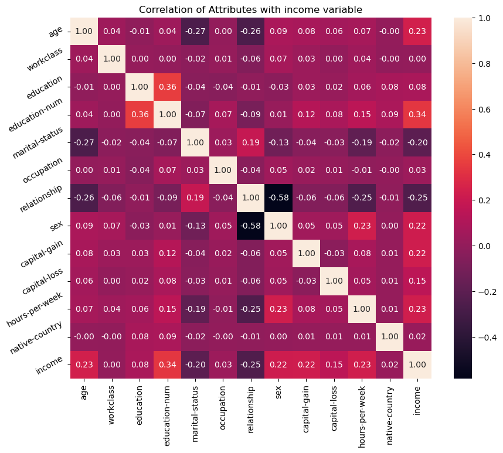

```python
plt.figure(figsize=(10,8))
plt.title('Correlation of Attributes with income variable')
a = sns.heatmap(correlation, square=True, annot=True, fmt='.2f', linecolor='white')
a.set_xticklabels(a.get_xticklabels(), rotation=90)
a.set_yticklabels(a.get_yticklabels(), rotation=30)
plt.show()
```